# FoodAtlas1

#### Student ID number: 201580313

#### Degree programme: integrated Phd and Msc in Data Analytics and Society

#### University: Leeds

#### Module code: ENVS615

#### Module title: Data Science Studio

#### Essay title: Using data analytics to understand the relationship between the obesity rate and the socio-demographic factors in United States

#### Date: 9th March 2021

# Using data analytics to understand the relationship between

# the obesity rate and the socio-demographic factors in the United States

## Content

Introduction

1. Find, prepare and explore a dataset
   1. Import the dataset
   2. Clean the dataset
      1. Remove all rows containing a null value
      2. Remove all rows containing missing value
   3. Explore the dataset
      1. Descriptive statistical analysis
      2. Study relationships between different continuous variables 1.Unsupervised learning
   4. K mean clustering
      1. Determination of the optimal number of clusters using the Elbow method
      2. K mean model
   5. K mean clustering with standardization
   6. Principal Component Analysis (PCA)
   7. Comparaison of three differents methods used to cluster data
      1. Calinski Harabasz score
      2. Silhouette score
      3. Characteristics of clusters
2. Supervised learning
   1. Multiple Linear Regression without cross-validation
      1. Without categorical variables
         1. Without logarithmic transformation
         2. With logarithmic transformation  
            1.With categorical variables
         3. Without logarithmic transformation
         4. With logarithmic transformation
   2. Multiple Linear Regression with cross-validation
      1. Without categorical variables
         1. Without logarithmic transformation
         2. With logarithmic transformation
      2. With categorical variables
         1. Without logarithmic transformation
         2. With logarithmic transformation
   3. Comparaison of Multiple Linear Regression models
      1. Preparation of data frames
      2. Check visually the quality of models
      3. Check the quality of models with different parameters

Conclusion

Abbreviations

References

Appendix

License

## Figures and Tables

1. Figures:
   1. Figure 1: Pairplot representing relationships between different variables
   2. Figure 2a: Determination of the optimal number of clusters k using the Elbow method
   3. Figure 2b: Determination of the optimal number of clusters k using the silhouette score
   4. Figure 3: Comparaisons of three different methods used to cluster data
   5. Figure 4: Heatmaps representing characteristics of clusters
   6. Figure 5: Observed values VS Predicted values for Multiple Linear Regression model without cross-validation (above) and with cross-validation (below)
2. Tables:
   1. Table 1: Final dataset after the cleaning step
   2. Table 2: Desciptive statistics (mean, standard derivation, quartiles, minimum and maximum) of continuous variables
   3. Table 3: Dataset containing continuous variables and dummies variables to conduct multiple linear regressions models

## Introduction

Obesity, defined as "an abnormal or excessive fat accumulation" (World Health Organization), is a major health issue of the twenty first century which can lead to medical complications such as melitus diabetes, cardiovascular diseases, some cancers and even to a prematured death. That is why, it is primordial to understand how different factors (i.e. genetic, physiological, psychological, behavioural and environmental) impact our physical condition. The aim of this exploratoy secondary data study is to understand the relationship between the rate obesity and economic and environmental factors.

The Food Environmental Atlas 2018 published on the platform for data science Kaggle under the license CC0: Public Domain by the United States Department of Agriculture in order to investigate interaction of socio-demographic and economic factors and the availability of healthy food options. The original dataset contains 250 variables. For this project, six variables were selected: two categorical variables the name of different states (1) and counties (2) and four continuous variables: the median household income (1) in 2015, the adult obesity rate in 2013 (2), percentages of population who has a low access to store in 2015 (4), household food insecurity (5) between 2013 and 2015. Each row represent a county in United States. As you can see, the rate of adult obesity were collected in 2013 while the other continuous variables were collected in 2015. It is the main limitation to use pre-collected data because we can not monitor the data collection and some variables which seems us to be interesting to study can be missing in a secondary data study.

First, the dataset will be imported, cleaned and explored with pairplot. Then, several clustering models (K mean clustering with and without standardization, Principal Component Analysis) will be performed and compared to choose the best efficient. Finally, relationships between different variables will be investigasted thanks to linear regression model.

Information

- All librairies and modules will be imported at the beginning of the report to avoid the overloading of the Python code.
- Some parts of code will be presented in comments, this code was used to describe the step (i.e. # Rename the columns) and to test the efficiency and the validity of the programm (i.e. # db1.loc[[268, 548, 1045, 1471, 2456, 2735, 2858, 2876, 2881], : ] ).
- In order to avoid the redundancy, the interpretation of intercept and coefficients will be conducted for some models: (1) Multiple linear regression without cross-validation without categorical variables without logarithmic transformation (2) Multiple linear regression without cross-validation without categorical variables with logarithmic transformation and (3) Multiple linear regression without cross-validation with categorical variables without logarithmic transformation
- An abbreviation table is available at the end of the report.
- You can find symbol map in the Appendix.

```python
# Importation of required different librairies and modules for the project
from IPython.display import Image
import timeit
import pandas as pd
import numpy as np
import seaborn as sns
import matplotlib.pyplot as plt
from numpy import exp, log1p, sqrt
from numpy.random import seed
from sklearn.cluster import KMeans
from sklearn.metrics import silhouette_score, calinski_harabasz_score
from sklearn.decomposition import PCA
from sklearn.preprocessing import scale
import statsmodels.formula.api as sm
from sklearn.linear_model import LinearRegression
from sklearn import metrics
from sklearn.metrics import r2_score
from sklearn.metrics import mean_squared_error as mse
from sklearn.metrics import mean_absolute_error as mae
from sklearn.model_selection import train_test_split
```

## I. Find, prepare and explore a dataset

### A. Import the dataset

```python
# Read the excel file which contains the dataset Food Atlas
db = pd.read_excel("DATASETFoodAtlas2018.xlsx")
# db
```

```python
db.shape
```

```
(3143, 6)
```

The initial dataset, imported from the excel file DATASETFoodAtlas2018, contained 3143 rows and 6 columns.

### B. Clean the dataset

In order to facilitate the reading of the dataset and its use in supervised and unsupervised learnings, columns were renamed.

```python
# Rename the columns
db.rename(columns={'MEDHHINC15': 'income','PCT_OBESE_ADULTS13':'obesity','PCT_LACCESS_POP15': 'store','FOODINSEC_13_15':'insecurity'}, inplace=True)
```

```python
# Check that the new names were taken into account
columns = db.columns
columns
```

```
Index(['State', 'County', 'income', 'store', 'obesity', 'insecurity'], dtype='object')
```

#### a. Remove all rows containing a null value

Whatever the variable, the value 0 is an irrelevant value. Indeed, it is not possible that the median income, percentages of food insecurity, low access to store and obesity in adults are null. That is why, in each column of continuous variables, we checked if we found a null value and removed all row containing this specific value.

```python
# db.loc[(db["store"] == 0.00)]
```

```python
# db.loc[(db["income"] == 0.00)]
```

```python
# db.loc[(db["insecurity"] == 0.00)]
```

```python
# db.loc[(db["obesity"] == 0.00)]
```

```python
db1=db.drop([268, 548, 1045, 1471, 2456, 2735, 2858, 2876, 2881])
# db1
```

```python
# Check that the row containing irrelevant value were removed
# db1.loc[[268, 548, 1045, 1471, 2456, 2735, 2858, 2876, 2881], : ]
```

```python
db1.shape
```

```
(3134, 6)
```

After this first step of cleaning, the dataset contained 3134 rows and 6 columns.

#### b. Remove all rows containing missing value

```python
# Detect if there are any missing values and in which column they are
db1.isnull().any()
```

```
State         False
County        False
income         True
store          True
obesity        True
insecurity    False
dtype: bool
```

Our dataset contains missing values in columns: income, store and obesity. Rows containing these missing values will be removed thanks to the inbuilt DataFrame function dropna().

```python
# Remove all row containing missing value
db0=db1.dropna()
```

```python
db0
```

|  | State | County | income | store | obesity | insecurity |
| --- | --- | --- | --- | --- | --- | --- |
| 0 | AL | Autauga | 56580.0 | 32.062255 | 34.1 | 17.6 |
| 1 | AL | Baldwin | 52387.0 | 16.767489 | 27.4 | 17.6 |
| 2 | AL | Barbour | 31433.0 | 22.105560 | 44.4 | 17.6 |
| 3 | AL | Bibb | 40767.0 | 4.230324 | 40.3 | 17.6 |
| 4 | AL | Blount | 50487.0 | 6.497380 | 34.6 | 17.6 |
| ... | ... | ... | ... | ... | ... | ... |
| 3138 | WY | Sweetwater | 71867.0 | 43.224074 | 31.7 | 13.2 |
| 3139 | WY | Teton | 83290.0 | 29.174370 | 12.7 | 13.2 |
| 3140 | WY | Uinta | 62968.0 | 22.189685 | 27.9 | 13.2 |
| 3141 | WY | Washakie | 56088.0 | 10.915407 | 27.7 | 13.2 |
| 3142 | WY | Weston | 60986.0 | 17.165192 | 29.2 | 13.2 |

3112 rows × 6 columns

Table 1: Final dataset after the cleaning step.

```python
db0.shape
```

```
(3112, 6)
```

The final dataset (See Table 1 above) contains 3112 rows and 6 columns. The rows represent different counties in the United States and the columns are two categorical variables: names of states and counties and four continuous variables: the median household income in 2015, the adult obesity rate in 2013, percentages of population who has a low access to store in 2015 and of household food insecurity between 2013 and 2015.

### C. Explore the dataset

#### a. Descriptive statistical analysis

```python
db0.describe()
```

|  | income | store | obesity | insecurity |
| --- | --- | --- | --- | --- |
| count | 3112.000000 | 3112.000000 | 3112.000000 | 3112.000000 |
| mean | 48570.440553 | 23.125320 | 31.018477 | 14.278856 |
| std | 12253.349090 | 19.561155 | 4.516685 | 2.459160 |
| min | 22894.000000 | 0.000126 | 11.800000 | 8.500000 |
| 25% | 40447.750000 | 11.020862 | 28.300000 | 12.400000 |
| 50% | 46794.000000 | 19.247921 | 31.200000 | 14.800000 |
| 75% | 54137.250000 | 28.869785 | 33.800000 | 15.400000 |
| max | 125900.000000 | 100.000001 | 47.600000 | 20.800000 |

Table 2: Desciptive statistics (mean, standard derivation, quartiles, minimum and maximum) of continuous variables

#### b. Study relationships between different continuous variables

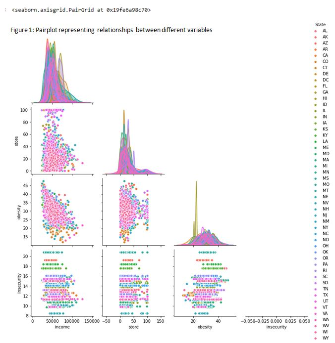

```python
# sns.pairplot(db0, corner = True, hue = "State")
Image("D:/pairplot.JPG")
```

```python
store = db0['store']
obesity = db0['obesity']
insecurity = db0['insecurity']
income = db0 ['income']
```

```python
a = np.corrcoef(income, obesity)
b = np.corrcoef(store, obesity)
c = np.corrcoef(insecurity, obesity)
```

```python
a
```

```
array([[ 1.        , -0.46017013],
       [-0.46017013,  1.        ]])
```

```python
b
```

```
array([[ 1.        , -0.09535827],
       [-0.09535827,  1.        ]])
```

```python
c
```

```
array([[1.        , 0.30284068],
       [0.30284068, 1.        ]])
```

With this pairplot performed with the librairy Seaborn, we can see that the rate of obesity is negatively moderately (r = -0.46) associated with the median household income and that the rate of obesity is weakly positively (r = 0.30) associated with the food insecurity rate. There is no relationship (r = -0.09) between the rate of obesity and the percentage of low access to stores.

After cleaning, preparing and exploring the dataset, we will cluster these data (See section II. Unsupervised learning) then we will investigate the relationship between all variables thanks to different multiple linear regression models (See section III. Supervised learning).

## II. Unsupervised learning

In order to cluster our data, we will use three methods: K-mean clustering without standardization, K-mean clustering with standardization and Principal Component Analysis. These methods are designed for continuous variables. That is why, the dataset will be slighty modified. Indeed, we removed the categorical variables.

```python
db2 = ["income", "store", "obesity","insecurity"]
# db2
```

```python
dba = db0[db2]
# dba
```

```python
dba.shape
```

```
(3112, 4)
```

The dataset, which will use for the unsupervised learning, contains 3112 rows representing the different counties of the United States and 4 continuous variables: the rate of obese adults in 2013, the median household income in 2015, the percentage of low access to stores in 2015 and the percentage of food insecurity in 2015.

### A. K mean clustering

#### a. Determination of the optimal number of clusters using the Elbow method

To determine the optimal number of clusters required for K-mean clustering, two methods are used: the Elbow method and the silhouette scores method.

```python
sil = []
kmax = 10
```

```python
for k in range(2, kmax+1):
  kmeans = KMeans(n_clusters = k).fit(dba)
  labels = kmeans.labels_
  sil.append(silhouette_score(dba, labels, metric = 'euclidean'))
```

```python
liste = [2,3,4,5,6,7,8,9,10]
```

```python
SSE = []
K = range(2,10)
for k in K:
    kmean = KMeans(n_clusters=k)
    kmean.fit(db0[db2])
    SSE.append(kmean.inertia_)
```

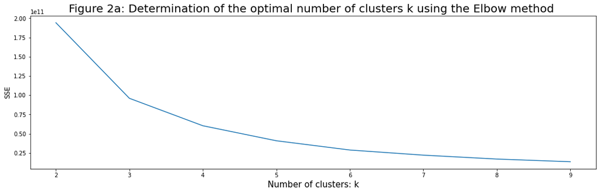

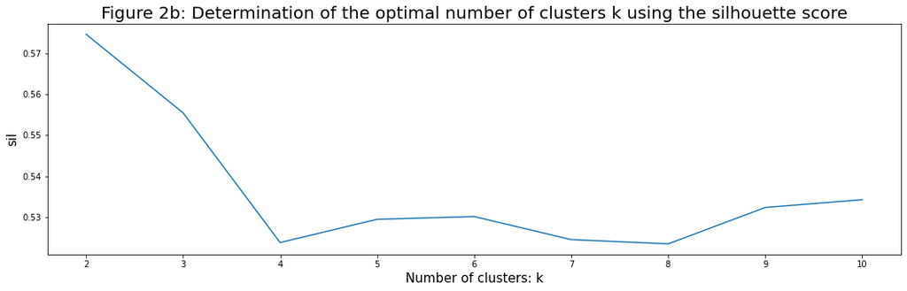

```python
plt.figure(figsize=(18,5))
plt.plot(K, SSE)
plt.xlabel('Number of clusters: k', size = 15)
plt.ylabel('SSE', size = 12)
plt.title('Figure 2a: Determination of the optimal number of clusters k using the Elbow method ', size=20)
plt.figure(figsize=(18,5))
plt.plot(liste, sil)
plt.xlabel('Number of clusters: k', size = 15)
plt.ylabel('sil', size = 15)
plt.title('Figure 2b: Determination of the optimal number of clusters k using the silhouette score', size=20)
plt.show()
```

For the Elbow method, the SSE is the sum of squared distances of samples to their closest cluster center. The smaller the value of sum of squared errors is and the Elbow chart decreases, the better the clusterization is.

The silhouette scores measures how a dot is close of other dots in the same cluster and how a dot is far of dots which belong to the nearest other cluster. A higher silhouette score is, the better the clusterization is.

With the Elbow method (See Figure 2a above), according the criteria of determination quote previousely, the ideal number of cluster can be 3, 4, 5 or 6. The silhouette score method can select the optimal number of clusters. Indeed, for k = 3, k = 4, k = 5 and k = 6, the higher value of silhouette score is for k = 3 (See Figure 2b above). Thus, the optimal number of clusters was determined: **k = 3**.

#### b. K mean model

```python
start = timeit.default_timer()
```

```python
kMean_model_without_standardization = KMeans(n_clusters = 3)
seed(1)
kMean_model_without_standardization.fit(db0[db2])
```

```
KMeans(n_clusters=3)
```

```python
k3_raw = pd.Series(kMean_model_without_standardization.labels_,index=dba.index)
# k3_raw
```

```python
stop = timeit.default_timer()
print('Time:', stop - start)
```

```
Time: 0.901527200000146
```

### B. K mean clustering with standardization

```python
start = timeit.default_timer()
```

```python
# Standardization (=subtracting the mean then dividing by the standard deviation)
db_stded = scale(db0[db2]) # calculate the standard variation observation minus the mean (x-mean(x))/standard deviation(x)
seed(1)
kMean_model_with_standardization = KMeans(n_clusters = 3)
kMean_model_with_standardization.fit(db_stded)
k3_std = pd.Series(kMean_model_with_standardization.labels_, index=db0.index)
# k3_std
```

```python
stop = timeit.default_timer()
print('Time:', stop - start)
```

```
Time: 0.19469430000026478
```

### C. Principal Component Analysis (PCA)

```python
start = timeit.default_timer()
```

```python
pca = PCA(n_components=2)
components = pca.fit_transform(db0[db2])
components = pd.DataFrame(components, index = dba.index,columns = ["C-1", "C-2"])
# components
seed(1)
estimator = KMeans(n_clusters = 3)
estimator.fit(components)
k3_pca = pd.Series(estimator.labels_,index=components.index)
#k3_pca
```

```python
stop = timeit.default_timer()
print('Time:', stop - start)
```

```
Time: 1.217440299998998
```

```python
var = pca.explained_variance_ratio_
print('Explained variation per principal component:', var)
```

```
Explained variation per principal component: [9.99997317e-01 2.53909255e-06]
```

For the Principal Component Analysis 99 % of the information is held by the first principal component, while the second principal component explained nothing. Less of 1 % of the information was lost.

### D. Comparaison of three differents methods used to cluster data:

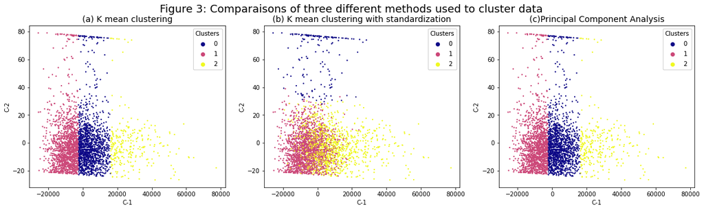

```python
fig, axs = plt.subplots(1, 3, figsize=(20, 5))
fig.suptitle ('Figure 3: Comparaisons of three different methods used to cluster data', size = 18)
ax = axs[0]
components.assign(labels=k3_raw)\
          .plot.scatter("C-1", "C-2",c="labels",s=1,cmap="plasma",colorbar=False,ax=ax)
ax.set_title("(a) K mean clustering", size=14, loc="center")
scatter1 = ax.scatter(components['C-1'], components['C-2'], c=k3_raw, s=1,cmap="plasma")
legend1 = ax.legend(*scatter1.legend_elements(),loc="upper right", title="Clusters")
ax.add_artist(legend1)
ax = axs[1]
components.assign(labels=k3_std)\
          .plot.scatter("C-1", "C-2",c="labels",s=1,cmap="plasma",colorbar=False,ax=ax)
ax.set_title("(b) K mean clustering with standardization", size=14, loc="center")
scatter2 = ax.scatter(components['C-1'], components['C-2'], c=k3_std, s=1,cmap="plasma")
legend2 = ax.legend(*scatter2.legend_elements(),loc="upper right", title="Clusters")
ax.add_artist(legend2)
ax = axs[2]
components.assign(labels=k3_pca)\
          .plot.scatter("C-1", "C-2",c="labels",s=1,cmap="plasma",colorbar=False,ax=ax)
ax.set_title("(c)Principal Component Analysis", size=14,  loc="center")
scatter3 = ax.scatter(components['C-1'], components['C-2'], c=k3_pca, s=1,cmap="plasma")
legend3 = ax.legend(*scatter3.legend_elements(),loc="upper right", title="Clusters")
ax.add_artist(legend3)
plt.show()
```

As we can visually see on these three different graphs, the method of K-mean with standardization clustering (Figure 3.(b)) does not allow a clear repartition between the clusters, all dots are merged and there are not really borders contrary to the other graphs. The three clusters seems to be better delimited with the method of k mean clustering without standardization clustering (Figure 3.(a)) and with the method of Principal Component Analysis (Figure 3.(c)) but it is impossible to perceive a difference between these two methods. That is why, the quality of clusters has to be evaluated.

First, we will determine how many counties are in the clusters 0, 1, 2 and 3. Then, in order check the quality of the clustering, the Calinski Harabasz score and the silhouette scores will be calculated. Finally, we will investigate charasteristics (i.e. mean, minimum and maximum) of each cluster.

- Composition of clusters

- K-mean clustering without standardization / Principal Component Analysis

```python
D1=k3_raw
D1.value_counts()
```

```
1    1476
0    1357
2     279
dtype: int64
```

```python
D3=k3_pca
D3.value_counts()
```

```
1    1476
0    1357
2     279
dtype: int64
```

```python
k3_pca
```

```
0       0
1       0
2       1
3       1
4       0
       ..
3138    2
3139    2
3140    0
3141    0
3142    0
Length: 3112, dtype: int32
```

```python
db0["County"][4]
```

```
'Blount'
```

```python
db0["County"][3]
```

```
'Bibb'
```

```python
db0["County"][3138]
```

```
'Sweetwater'
```

- K-mean clustering with standardization

```python
D2=k3_std
D2.value_counts()
```

```
1    1766
2    1169
0     177
dtype: int64
```

```python
D2
```

```
0       1
1       1
2       1
3       1
4       1
       ..
3138    2
3139    2
3140    2
3141    2
3142    2
Length: 3112, dtype: int32
```

```python
D2.loc[(D2 == 0.00)]
```

```
67      0
70      0
71      0
72      0
76      0
       ..
2918    0
2927    0
2965    0
2975    0
2988    0
Length: 177, dtype: int32
```

```python
db0["County"][76]
```

```
'Hoonah-Angoon'
```

#### a. Calinski Harabasz score

```python
chs_raw = calinski_harabasz_score(db0[db2],k3_raw)
chs_std = calinski_harabasz_score(db0[db2],k3_std)
chs_pca = calinski_harabasz_score(db0[db2],k3_pca)
pd.Series({"Raw": chs_raw,"Standardised": chs_std,"PCA": chs_pca})
```

```
Raw             6015.920099
Standardised     671.885353
PCA             6015.920099
dtype: float64
```

#### b. Silhouette score

```python
sil_raw = silhouette_score(db0[db2], k3_raw,metric="euclidean")
sil_std = silhouette_score(db0[db2], k3_std,metric="euclidean")
sil_pca = silhouette_score(db0[db2], k3_pca,metric="euclidean")
pd.Series({"Raw": sil_raw,"Standardised": sil_std,"PCA": sil_pca,})
```

```
Raw             0.555449
Standardised    0.069054
PCA             0.555449
dtype: float64
```

### E. Caracteristics of clusters

```python
g= db0[db2]\
      .groupby(k3_raw)
```

```python
h= db0[db2]\
      .groupby(k3_std)
```

```python
h.size()\
.sort_values()
```

```
0     177
2    1169
1    1766
dtype: int64
```

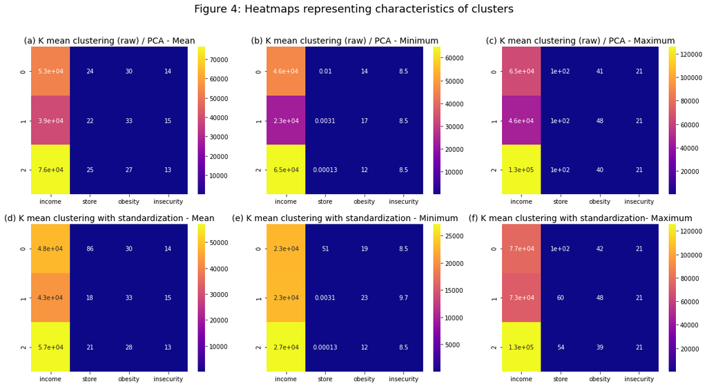

```python
fig, axs = plt.subplots(2, 3, figsize=(20, 10))
fig.suptitle('Figure 4: Heatmaps representing characteristics of clusters', size = 18)
ax = axs[0][0]
ax.set_title("(a) K mean clustering (raw) / PCA - Mean", size=14, loc="center")
sns.heatmap(g.mean(), cmap='plasma', annot = True, cbar = True, ax = ax);
ax = axs[0][1]
ax.set_title("(b) K mean clustering (raw) / PCA - Minimum", size=14, loc="center")
sns.heatmap(g.min(), cmap='plasma', annot = True, cbar = True, ax = ax);
ax = axs[0][2]
ax.set_title("(c) K mean clustering (raw) / PCA - Maximum", size=14, loc="center")
sns.heatmap(g.max(), cmap='plasma', annot = True, cbar = True, ax =ax);
ax = axs[1][0]
ax.set_title("(d) K mean clustering with standardization - Mean", size=14, loc="center")
sns.heatmap(h.mean(), cmap='plasma', annot = True, cbar = True, ax = ax);
ax = axs[1][1]
ax.set_title("(e) K mean clustering with standardization - Minimum", size=14, loc="center")
sns.heatmap(h.min(), cmap='plasma', annot = True, cbar = True, ax = ax);
ax = axs[1][2]
ax.set_title("(f) K mean clustering with standardization- Maximum", size=14, loc="center")
sns.heatmap(h.max(), cmap='plasma', annot = True, cbar = True, ax =ax);
```

## III. Supervised learning

In order to conduct supervised learning, we have to obtain dummies variables for our categorical variables. They can take only the value 0 or 1 to indicate its presence or its absence.

```python
# Otbtain dummies variables for the two categorical variables: state and county
state = pd.get_dummies(db0["State"])
county = pd.get_dummies(db0["County"])
```

```python
df =pd.concat([db[["obesity", "income","insecurity","store"]],state, county], axis=1)
# df
```

```python
dff= df.dropna()
```

```python
dff
```

|  | obesity | income | insecurity | store | AK | AL | AR | AZ | CA | CO | ... | Yoakum | Yolo | York | Young | Yuba | Yukon-Koyukuk | Yuma | Zapata | Zavala | Ziebach |
| --- | --- | --- | --- | --- | --- | --- | --- | --- | --- | --- | --- | --- | --- | --- | --- | --- | --- | --- | --- | --- | --- |
| 0 | 34.1 | 56580.0 | 17.6 | 32.062255 | 0.0 | 1.0 | 0.0 | 0.0 | 0.0 | 0.0 | ... | 0.0 | 0.0 | 0.0 | 0.0 | 0.0 | 0.0 | 0.0 | 0.0 | 0.0 | 0.0 |
| 1 | 27.4 | 52387.0 | 17.6 | 16.767489 | 0.0 | 1.0 | 0.0 | 0.0 | 0.0 | 0.0 | ... | 0.0 | 0.0 | 0.0 | 0.0 | 0.0 | 0.0 | 0.0 | 0.0 | 0.0 | 0.0 |
| 2 | 44.4 | 31433.0 | 17.6 | 22.105560 | 0.0 | 1.0 | 0.0 | 0.0 | 0.0 | 0.0 | ... | 0.0 | 0.0 | 0.0 | 0.0 | 0.0 | 0.0 | 0.0 | 0.0 | 0.0 | 0.0 |
| 3 | 40.3 | 40767.0 | 17.6 | 4.230324 | 0.0 | 1.0 | 0.0 | 0.0 | 0.0 | 0.0 | ... | 0.0 | 0.0 | 0.0 | 0.0 | 0.0 | 0.0 | 0.0 | 0.0 | 0.0 | 0.0 |
| 4 | 34.6 | 50487.0 | 17.6 | 6.497380 | 0.0 | 1.0 | 0.0 | 0.0 | 0.0 | 0.0 | ... | 0.0 | 0.0 | 0.0 | 0.0 | 0.0 | 0.0 | 0.0 | 0.0 | 0.0 | 0.0 |
| ... | ... | ... | ... | ... | ... | ... | ... | ... | ... | ... | ... | ... | ... | ... | ... | ... | ... | ... | ... | ... | ... |
| 3138 | 31.7 | 71867.0 | 13.2 | 43.224074 | 0.0 | 0.0 | 0.0 | 0.0 | 0.0 | 0.0 | ... | 0.0 | 0.0 | 0.0 | 0.0 | 0.0 | 0.0 | 0.0 | 0.0 | 0.0 | 0.0 |
| 3139 | 12.7 | 83290.0 | 13.2 | 29.174370 | 0.0 | 0.0 | 0.0 | 0.0 | 0.0 | 0.0 | ... | 0.0 | 0.0 | 0.0 | 0.0 | 0.0 | 0.0 | 0.0 | 0.0 | 0.0 | 0.0 |
| 3140 | 27.9 | 62968.0 | 13.2 | 22.189685 | 0.0 | 0.0 | 0.0 | 0.0 | 0.0 | 0.0 | ... | 0.0 | 0.0 | 0.0 | 0.0 | 0.0 | 0.0 | 0.0 | 0.0 | 0.0 | 0.0 |
| 3141 | 27.7 | 56088.0 | 13.2 | 10.915407 | 0.0 | 0.0 | 0.0 | 0.0 | 0.0 | 0.0 | ... | 0.0 | 0.0 | 0.0 | 0.0 | 0.0 | 0.0 | 0.0 | 0.0 | 0.0 | 0.0 |
| 3142 | 29.2 | 60986.0 | 13.2 | 17.165192 | 0.0 | 0.0 | 0.0 | 0.0 | 0.0 | 0.0 | ... | 0.0 | 0.0 | 0.0 | 0.0 | 0.0 | 0.0 | 0.0 | 0.0 | 0.0 | 0.0 |

3112 rows × 1870 columns

### A. Multiple Linear Regression without cross-validation

#### a. Multiple Linear Regression without categorical variables

##### i. Without logarithmic transformation

```python
start = timeit.default_timer()
```

```python
lm_raw = sm.ols("obesity  ~  income + store + insecurity", dff).fit()
lm_raw
```

```
<statsmodels.regression.linear_model.RegressionResultsWrapper at 0x2e0054abbe0>
```

```python
stop = timeit.default_timer()
print('Time:', stop - start)
```

```
Time: 0.11022479999883217
```

```python
lm_raw.summary()
```

OLS Regression Results

| Dep. Variable: | obesity | R-squared: | 0.254 |
| --- | --- | --- | --- |
| Model: | OLS | Adj. R-squared: | 0.253 |
| Method: | Least Squares | F-statistic: | 351.9 |
| Date: | Tue, 02 Mar 2021 | Prob (F-statistic): | 9.88e-197 |
| Time: | 16:10:32 | Log-Likelihood: | -8652.4 |
| No. Observations: | 3112 | AIC: | 1.731e+04 |
| Df Residuals: | 3108 | BIC: | 1.734e+04 |
| Df Model: | 3 |  |  |
| Covariance Type: | nonrobust |  |  |

|  | coef | std err | t | P>\|t\| | [0.025 | 0.975] |
| --- | --- | --- | --- | --- | --- | --- |
| Intercept | 33.3874 | 0.574 | 58.185 | 0.000 | 32.262 | 34.512 |
| income | -0.0002 | 5.9e-06 | -25.505 | 0.000 | -0.000 | -0.000 |
| store | -0.0129 | 0.004 | -3.604 | 0.000 | -0.020 | -0.006 |
| insecurity | 0.3666 | 0.029 | 12.474 | 0.000 | 0.309 | 0.424 |

| Omnibus: | 61.972 | Durbin-Watson: | 1.179 |
| --- | --- | --- | --- |
| Prob(Omnibus): | 0.000 | Jarque-Bera (JB): | 74.098 |
| Skew: | -0.282 | Prob(JB): | 8.13e-17 |
| Kurtosis: | 3.504 | Cond. No. | 4.11e+05 |

Warnings:  
[1] Standard Errors assume that the covariance matrix of the errors is correctly specified.  
[2] The condition number is large, 4.11e+05. This might indicate that there are  
strong multicollinearity or other numerical problems.

```python
lm_raw.rsquared
```

```
0.2535490878068706
```

The model explains only 25 % of fitted data. The intercept means that if the median household income, percentages of low access to stores and food insecurity in 2015 are null and without the influence of the location (states and counties), the rate of adult obesity will be of 33.39 %. However, it is not plausible that the median household income, percentages of low access to stores and food insecurity are equal to 0. Thus, this coefficient of regression is meaningless for this model and its only use is to place the regression line in the right place.

If the p-value is inferior to 0.05, the coefficients are significant. For the median household income, the coefficient of - 0.0002 means that the median household income increases of 10 000, the rate of obesity decreases of 2 % when the all other variables are constant. For the percentage of food insecurity, the coefficient of 0.3666 means that if the percentage of food insecurity increases of 0.36 %, the rate of adult obesity increases of 1 % when the all other variables are constant. For the percentage of low access to stores, its coefficient (-0,0129) means that if the percentage of low access to stores increases of 0,00129 %, the rate of obesity decreases of 1 % when the all other variables are constant.

##### ii. With logarithmic transformation

```python
start = timeit.default_timer()
```

```python
lm_log = sm.ols("np.log1p(obesity)  ~  income + store + insecurity", dff).fit()
lm_log
```

```
<statsmodels.regression.linear_model.RegressionResultsWrapper at 0x2e0044f6970>
```

```python
stop = timeit.default_timer()
print('Time:', stop - start)
```

```
Time: 0.054870100000698585
```

```python
lm_log.rsquared
```

```
0.25140432451687056
```

```python
lm_log.params
```

```
Intercept     3.529316
income       -0.000005
store        -0.000388
insecurity    0.012315
dtype: float64
```

```python
# Calculate the exponent of the intercept
exp(3.529316)
```

```
34.10063480163766
```

```python
# Coefficient for the "income" variable
(exp (-0.000005)-1)*100
```

```
-0.0004999987500031722
```

```python
# Coefficient for the "store" variable
(exp(-0.000388)-1)*100
```

```
-0.0387924737734191
```

```python
# Coefficient for the "insecurity" variable
(exp(0.012315)-1) * 100
```

```
1.2391141853779652
```

The Multiple Linear Regression without categorical variables but with logarithmic transformation explains also 25 % of fitted data. The interpretation of the intercept and coefficients is a little different compared to the interpretation of the intercept and coefficients. Indeed, we use the same method but as only our dependent variable was log-transformed, we calculated the exponent of the coefficient, then we substract one from this number and finally we multiply by 100 (See the three last lines of Python code above). After this step, the interpretation of coefficient is the same that for the multiple linear regression model without categorical variable and without logarrithmic transformation.

#### b. Multiple Linear Regression

##### i. Without logarithmic transformation

```python
start = timeit.default_timer()
```

```python
lm1_raw = sm.ols("obesity  ~  income + store + insecurity + state + county", dff).fit()
lm1_raw
```

```
<statsmodels.regression.linear_model.RegressionResultsWrapper at 0x2e003068fa0>
```

```python
stop = timeit.default_timer()
print('Time:', stop - start)
```

```
Time: 12.04062630000044
```

```python
# lm1_raw.summary()
```

```python
lm1_raw.params
```

```
Intercept       18.662412
income          -0.000130
store            0.002763
insecurity       1.283155
state[0]        -2.832816
                  ...
county[1810]     0.040562
county[1811]     0.715170
county[1812]    -4.376522
county[1813]    -4.291061
county[1814]     8.164838
Length: 1870, dtype: float64
```

```python
columns1 = dff.columns
```

```python
columns1
```

```
Index(['obesity', 'income', 'insecurity', 'store', 'AK', 'AL', 'AR', 'AZ',
       'CA', 'CO',
       ...
       'Yoakum', 'Yolo', 'York', 'Young', 'Yuba', 'Yukon-Koyukuk', 'Yuma',
       'Zapata', 'Zavala', 'Ziebach'],
      dtype='object', length=1870)
```

```python
columns1[1675]
```

```
'Todd'
```

```python
columns1[1447]
```

```
'Rockland'
```

```python
lm1_raw.rsquared
```

```
0.8382924903797242
```

The model of multiple linear regression with categorical variables explains 84% of fitted data: it is almost four times more than the model of multiple linear regression without categorical variables. This means that the median household income, the percentage of food insecurity and the percentage of low access to stores in 2015 are not the only factors which impact the obesity rate in adults in the United States. The geographical location has also an impact on the rate of obesity. The intercept means that if the median household income, percentages of low access to stores and food insecurity in 2015 are null and with the influence of the location (states and counties), the rate of adult obesity will be of 18.66 %. However, it is not plausible that the median household income, percentages of low access to stores and food insecurity are equal to 0. Thus, this coefficient of regression is meaningless for this model and its only use is to place the regression line in the right place. If the p-value is inferior to 0.05, the coefficients are significant. It is the case for the median household income and the percentage of food insecurity but not for the percentage of low access to stores. For the median household income, the coefficient of - 0.000130 means that the median household income increases of 10 000, the rate of obesity decreases of 1.3 %. For the percentage of food insecurity, the coefficient 1.283155 means that the rate of adult obesity increases of 1 %, while the percentage of food insecurity increases of 1.28 % when the all other variables are constant.

Concerning the coefficient for dummy variables, we have two references: one for the categorical variable "states": Wyoming and one for the categorical variable "counties": Ziebach. If the coefficient for dummy variables is positive, it means that on average the dependent variable is higher for this level of our categorical variable than for the reference. If the coefficient for dummy variables is negative, it means that on average the dependent variable is lower for this level of our categorical variable than for the reference. For example, Concerning the independent categorical variable "state", on average the rate of obesity in 2013 was significantly higher in Alaska, the District of Columbia, Hawaii, Idaho, Indiana, Iowa, Maine, Michigan, Mississippi, Nebraska, New Jersey, New York, Ohio, Oregon, Rhode Island , SC South Carolina, Utah and West Virginia than in Wyoming. On average the rate of obesity in 2013 was significantly lower in Arizona, California, Florida, Kansas, Kentucky, Louisiana, Minnesota, New Mexico, North Carolina, Oklahoma, Tennessee, and Wisconsin than in Wyoming. Concerning the independant categorical variable "counties", for example on average the rate of obesity in 2013 was significantly 6.14 higher in Todd than in Ziebach and was significantly 9.02 lower in Rockland than in Ziebach.

##### ii. With logarithmic transformation

```python
start = timeit.default_timer()
```

```python
lm1_log = sm.ols("np.log1p(obesity)  ~  income + store + insecurity + state + county", dff).fit()
lm1_log
```

```
<statsmodels.regression.linear_model.RegressionResultsWrapper at 0x2e006c17640>
```

```python
stop = timeit.default_timer()
print('Time:', stop - start)
```

```
Time: 10.601332199999888
```

```python
lm1_log.rsquared
```

```
0.8545143025027133
```

```python
lm1_log.params
```

```
Intercept       2.165007
income         -0.000004
store           0.000116
insecurity      0.104454
state[0]        0.000210
                  ...
county[1810]   -0.029680
county[1811]    0.054691
county[1812]   -0.144218
county[1813]   -0.137206
county[1814]    0.212197
Length: 1870, dtype: float64
```

```python
#lm1_log.summary()
```

```python
lm_raw.rsquared
```

```
0.2535490878068706
```

```python
lm_log.rsquared
```

```
0.25140432451687056
```

As the multiple linear regression model without categorical variables with logaritmic, to interpret the intercept we have to calculate its exponent and for the coefficients we have to calculate the exponent of the coefficient, then substract one from this number and finally multiply by 100.

### B. Multiple Linear Regression with cross-validation

#### a. Multiple Linear Regression without categorical variables

##### i. Without logarithmic transformation

```python
start = timeit.default_timer()
```

```python
X=dff[['income', 'insecurity', 'store']]
y=dff[['obesity']]
```

```python
# X
# y
```

```python
X_train, X_test, y_train, y_test = train_test_split(X,y,test_size=0.8)
```

```python
regressor = LinearRegression()
MLR_Raw = regressor.fit(X_train,y_train)
```

```python
MLR_Raw
```

```
LinearRegression()
```

```python
y_pred_MLR_Raw = regressor.predict(X_test)
y_pred_MLR_Raw
```

```
array([[28.68374642],
       [32.20030695],
       [34.97058313],
       ...,
       [31.88461303],
       [33.06762657],
       [32.48135645]])
```

```python
stop = timeit.default_timer()
print('Time:', stop - start)
```

```
Time: 0.49962650000088615
```

```python
r_sq1 = MLR_Raw.score(X_test,y_test)
print('The coefficient of determination is: r^2', r_sq1)
```

```
The coefficient of determination is: r^2 0.24809326096706064
```

```python
regressor.intercept_
```

```
array([35.50514003])
```

```python
coefficients = print('coefficients:', MLR_Raw.coef_)
```

```
coefficients: [[-1.61520650e-04  2.46631997e-01 -8.69420703e-03]]
```

```python
# X_train
#X_test
# y_train
# y_test
```

##### ii. With logarithmic transformation

```python
start = timeit.default_timer()
```

```python
X=dff[['income', 'insecurity', 'store']]
y1= np.log1p(obesity)
```

```python
X_train, X_test, y_train, y_test_1 = train_test_split(X,y1,test_size=0.8)
```

```python
regressor = LinearRegression()
MLR_Log = regressor.fit(X_train,y_train)
```

```python
y_pred_MLR_Log = regressor.predict(X_test)
y_pred_MLR_Log
```

```
array([3.53100078, 3.47219006, 3.50538791, ..., 3.35011674, 3.47522833,
       3.52286201])
```

```python
stop = timeit.default_timer()
print('Time:', stop - start)
```

```
Time: 0.06436580000081449
```

```python
r_sq2 = MLR_Log.score(X_test, y_test_1)
print('The coefficient of determination is: r^2', r_sq2)
```

```
The coefficient of determination is: r^2 0.24922760001571476
```

```python
regressor.intercept_
```

```
3.4971405710757084
```

```python
coefficients = print('coefficiients:', MLR_Log.coef_)
```

```
coefficiients: [-4.90249470e-06  1.46120438e-02 -4.92398352e-04]
```

#### b. Multiple Linear Regression with categorical variables

##### i. Without logarithmic transformation

```python
start = timeit.default_timer()
```

```python
dff2 = dff.drop(columns=["obesity"])
```

```python
X=dff2
y=dff[['obesity']]
```

```python
X_train, X_test, y_train, y_test = train_test_split(X,y,test_size=0.8)
```

```python
regressor = LinearRegression()
MLR1_Raw = regressor.fit(X_train,y_train)
```

```python
y_pred_MLR1_Raw = regressor.predict(X_test)
y_pred_MLR1_Raw
```

```
array([[45.47635449],
       [35.61600363],
       [31.84317445],
       ...,
       [27.86214807],
       [32.70155679],
       [29.48726651]])
```

```python
stop = timeit.default_timer()
print('Time:', stop - start)
```

```
Time: 1.6464209000005212
```

```python
r_sq3 = MLR1_Raw.score(X_test, y_test)
print('The coefficient of determination is: r^2', r_sq3)
```

```
The coefficient of determination is: r^2 0.23669013305675934
```

```python
MLR1_Raw.intercept_
```

```
array([33.76846209])
```

```python
coefficients = print('coefficients:', MLR1_Raw.coef_)
```

```
coefficients: [[-1.25772867e-04  2.20045355e-01 -1.19773665e-02 ... -4.17459344e+00
   0.00000000e+00  0.00000000e+00]]
```

##### ii. With logarithmic transformation

```python
# np.log1p(obesity)
```

```python
X=dff2
y1= np.log1p(obesity)
```

```python
X_train, X_test, y_train, y_test_1 = train_test_split(X,y1,test_size=0.8)
```

```python
regressor = LinearRegression()
MLR1_log = regressor.fit(X_train,y_train)
```

```python
y_pred_MLR1_log = regressor.predict(X_test)
y_pred_MLR1_log
```

```
array([ 1.15239981e+06,  3.57156201e+00, -3.43090218e+04, ...,
       -3.95942502e+04, -4.69039844e+05, -3.43091756e+04])
```

```python
r_sq4 = MLR1_log.score(X_test, y_test_1)
print('coefficient of determination:', r_sq4)
```

```
coefficient of determination: -47166888041698.06
```

```python
MLR1_log.score(X_train, y_train)
```

```
0.9440109705988031
```

```python
MLR1_log.get_params()
```

```
{'copy_X': True, 'fit_intercept': True, 'n_jobs': None, 'normalize': False}
```

```python
MLR1_log.intercept_
```

```
-31532637.931284677
```

```python
coefficients = print('coefficients:', MLR1_log.coef_)
```

```
coefficients: [-3.59443868e-06  2.33756341e+06 -9.30751933e-04 ...  0.00000000e+00
  0.00000000e+00  0.00000000e+00]
```

```python
print('intercept:', MLR1_log.intercept_)
```

```
intercept: -31532637.931284677
```

### C. Comparaison of Multiple Linear Regression models with cross-validation

#### a. Preparation of data frames

```python
dataframe_y_test = y_test
# dataframe_y_test
```

```python
df.to_excel("y_test.xlsx")
```

```python
# dataframe_y_test.to_excel("D:\DATA.xlsx")
```

```python
data_y_test = pd.read_excel("DATA.xlsx")
```

```python
# data_y_test
```

```python
dataframe_y_pred_MLR1_Raw=pd.DataFrame(y_pred_MLR1_Raw, columns=['MLR1_Raw'])
# dataframe_y_pred_MLR1_Raw
```

```python
# dataframe_y_pred_MLR1_Raw.to_excel("D:\DATA1.xlsx")
```

```python
data_MLR1_Raw = pd.read_excel("DATA1.xlsx")
```

```python
# data_MLR1_Raw
```

```python
dataset_MLR1_Raw = pd.merge(data_MLR1_Raw,data_y_test, on='Index')
```

```python
# dataset_MLR1_Raw
```

```python
df_dataset_MLR1_Raw = dataset_MLR1_Raw.drop(["Index"], axis=1)
# df_dataset_MLR1_Raw
```

```python
dataframe_y_pred_MLR_Raw = pd.DataFrame(y_pred_MLR_Raw, columns=['MLR_Raw'])
# dataframe_y_pred_MLR_Raw
```

```python
# dataframe_y_pred_MLR_Raw.to_excel("D:\DATA2.xlsx")
```

```python
data_MLR_Raw = pd.read_excel("DATA2.xlsx")
```

```python
# data_MLR_Raw
```

```python
dataset_MLR_Raw = pd.merge(data_MLR_Raw,data_y_test, on='Index')
```

```python
# dataset_MLR_Raw
```

```python
df_dataset_MLR_Raw = dataset_MLR_Raw.drop(["Index"], axis=1)
# df_dataset_MLR_Raw
```

```python
dataframe_y_pred_MLR1_Log = pd.DataFrame(y_pred_MLR1_log, columns=['MLR1_Log'])
# dataframe_y_pred_MLR1_Log
```

```python
# dataframe_y_pred_MLR1_Log.to_excel("D:\DATA3.xlsx")
```

```python
data_MLR1_Log = pd.read_excel("DATA3.xlsx")
```

```python
# data_MLR1_Log
```

```python
dataset_MLR1_Log = pd.merge(data_MLR1_Log, data_y_test, on='Index')
```

```python
# dataset_MLR1_Log
```

```python
df_dataset_MLR1_Log  = dataset_MLR1_Log.drop(["Index"], axis=1)
# df_dataset_MLR1_Log
```

```python
df_dataset_MLR1_Log.rename(columns={'Truth_x': 'Truth'}, inplace=True)
```

```python
# df_dataset_MLR1_Log
```

```python
df1_dataset_MLR1_Log = df_dataset_MLR1_Log.drop(["Truth"], axis=1)
# df1_dataset_MLR1_Log
```

```python
dataframe_y_pred_MLR_Log = pd.DataFrame(y_pred_MLR_Log, columns=['MLR_Log'])
# dataframe_y_pred_MLR_Log
```

```python
# dataframe_y_pred_MLR_Log.to_excel("D:\DATA4.xlsx")
```

```python
data_MLR_Log = pd.read_excel("DATA4.xlsx")
```

```python
# data_MLR_Log
```

```python
dataset_MLR_Log = pd.merge(data_MLR_Log, data_y_test, on='Index')
```

```python
# dataset_MLR_Log
```

```python
df1_dataset_MLR_Log = dataset_MLR_Log.drop(["Truth","Index"], axis=1)
# df1_dataset_MLR_Log
```

```python
res_LM = pd.DataFrame({"LM_Raw": lm_raw.fittedvalues,"LM_Log": lm_log.fittedvalues,"LM1_Raw": lm1_raw.fittedvalues,"LM1_Log": lm1_log.fittedvalues,"Truth": db0["obesity"]})
# res_LM
```

#### b. Check visually the quality of models

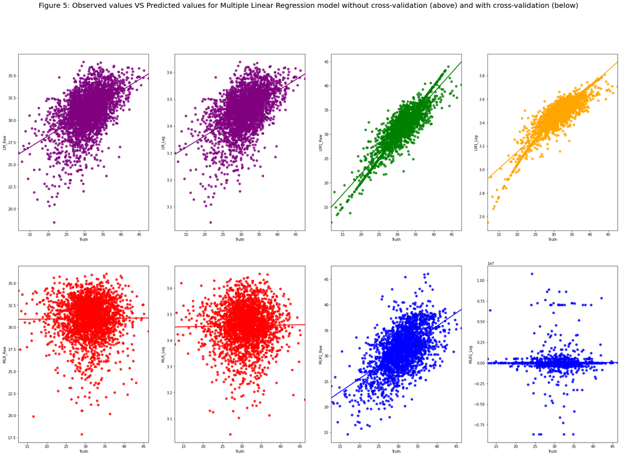

```python
fig, axs = plt.subplots(2, 4, figsize=(30, 20))
fig.suptitle('Figure 5: Observed values VS Predicted values for Multiple Linear Regression model without cross-validation (above) and with cross-validation (below)', size = 20)
ax = axs[0][0]
sns.regplot("Truth", "LM_Raw", res_LM,ci=None,ax=ax, color = 'purple');
ax = axs[0][1]
sns.regplot("Truth", "LM_Log", res_LM,ci=None,ax=ax, color = 'purple');
ax = axs[0][2]
sns.regplot("Truth", "LM1_Raw", res_LM,ci=None,ax=ax, color ='green');
ax = axs[0][3]
sns.regplot("Truth", "LM1_Log", res_LM,ci=None,ax=ax, color ='orange');
ax = axs[1][0]
sns.regplot("Truth", "MLR_Raw",df_dataset_MLR_Raw ,ci=None,ax=ax, color ='red');
ax = axs[1][1]
sns.regplot("Truth", "MLR_Log", dataset_MLR_Log,ci=None,ax=ax, color ='red');
ax = axs[1][2]
sns.regplot("Truth", "MLR1_Raw", df_dataset_MLR1_Raw,ci=None,ax=ax, color ='blue');
ax = axs[1][3]
sns.regplot("Truth", "MLR1_Log", df_dataset_MLR1_Log ,ci=None,ax=ax, color ='blue');
```

#### c. Check the quality of models with different parameters

- Coefficient of determination (R^2)

- Multiple Linear Regression without cross - validation

```python
r_squared = pd.Series({"LM_Raw": lm_raw.rsquared,"LM_Log": lm_log.rsquared,"LM1_Raw": lm1_raw.rsquared ,"LM1_Log": lm1_log.rsquared })
r_squared
```

```
LM_Raw     0.253549
LM_Log     0.251404
LM1_Raw    0.838292
LM1_Log    0.854514
dtype: float64
```

- Multiple Linear Regression with cross - validation

```python
r_squared = pd.Series({"MLR_Raw": r_sq1,"MLR_Log": r_sq2 ,"MLR11_Raw": r_sq3 ,"MLR1_Log": r_sq4 })
r_squared
```

```
MLR_Raw      2.480933e-01
MLR_Log      2.492276e-01
MLR11_Raw    2.366901e-01
MLR1_Log    -4.716689e+13
dtype: float64
```

- Mean Absolute Error (MAE)

- Multiple Linear Regression without cross - validation

```python
maes = pd.Series({"LM_Raw": mae(res_LM["Truth"], res_LM["LM_Raw"]),"LM_Log": mae(res_LM["Truth"], exp(res_LM["LM_Log"])),"LM1_Raw": mae(res_LM["Truth"],res_LM["LM1_Raw"]),"LM1_Log": mae(res_LM["Truth"],exp(res_LM["LM1_Log"]))})
maes
```

```
LM_Raw     3.054267
LM_Log     3.087422
LM1_Raw    1.071500
LM1_Log    1.600715
dtype: float64
```

- Multiple Linear Regression with cross - validation

```python
maes = pd.Series({"MLR_Raw": mae(y_pred_MLR_Raw,y_test), "MLR_Log": mae(y_pred_MLR_Log, y_test), "MLR1_Raw": mae(y_pred_MLR1_Raw, y_test), "MLR1_Log": mae(y_pred_MLR1_log, y_test),})
maes
```

```
MLR_Raw          3.836855
MLR_Log         27.528201
MLR1_Raw         3.048675
MLR1_Log    275363.519240
dtype: float64
```

- Mean Squared Error (MSE)

- Multiple Linear Regression without cross - validation

```python
mses = pd.Series({"LM_Raw": mse(res_LM["Truth"], res_LM["LM_Raw"]),"LM_Log": mse(res_LM["Truth"],exp(res_LM["LM_Log"])),"LM1_Raw": mse(res_LM["Truth"],res_LM["LM1_Raw"]),"LM1_Log": mse(res_LM["Truth"], exp(res_LM["LM1_Log"])),})
mses
```

```
LM_Raw     15.223038
LM_Log     15.752046
LM1_Raw     3.297845
LM1_Log     4.200332
dtype: float64
```

- Multiple Linear Regression with cross - validation

```python
mses = pd.Series({"MLR_Raw": mse(y_pred_MLR_Raw,y_test), "MLR_Log": mse(y_pred_MLR_Log, y_test), "MLR1_Raw": mse(y_pred_MLR1_Raw, y_test), "MLR1_Log": mse(y_pred_MLR1_log,y_test)})
mses
```

```
MLR_Raw     2.482030e+01
MLR_Log     7.779103e+02
MLR1_Raw    1.535245e+01
MLR1_Log    1.068842e+12
dtype: float64
```

- Root of Mean Squared Error (RMSE)

- Multiple Linear Regression without cross - validation

```python
mses = pd.Series({"LM_Raw": sqrt(mse(res_LM["Truth"], res_LM["LM_Raw"])),"LM_Log": sqrt(mse(res_LM["Truth"],exp(res_LM["LM_Log"]))),"LM1_Raw": sqrt(mse(res_LM["Truth"],res_LM["LM1_Raw"])),"LM1_Log": sqrt(mse(res_LM["Truth"], exp(res_LM["LM1_Log"]))),})
mses
```

```
LM_Raw     3.901671
LM_Log     3.968885
LM1_Raw    1.815997
LM1_Log    2.049471
dtype: float64
```

- Multiple Linear Regression with cross - validation

```python
mses = pd.Series({"MLR_Raw": sqrt(mse(y_pred_MLR_Raw,y_test)), "MLR_Log": sqrt(mse(y_pred_MLR_Log, y_test)), "MLR1_Raw": sqrt(mse(y_pred_MLR1_Raw, y_test)), "MLR1_Log": sqrt(mse(y_pred_MLR1_log,y_test))})
mses
```

```
MLR_Raw     4.981997e+00
MLR_Log     2.789104e+01
MLR1_Raw    3.918220e+00
MLR1_Log    1.033848e+06
dtype: float64
```

The coefficient of determination: R^2 is defined as the proportion of the variance in the dependent variable that is predictable from the independent variables. The higher the coefficient of determination is, the better the model is. Mean Squared Error is defined as the average of the square of the difference between actual and estimated values. The Root of Mean squared Error is the standard deviation of the residuals: it is a measure to show how far the dots are from the line of regression. Mean Absolute Error is defined as the average of all absolute errors between the observed value and the true value. The lower the Mean Squared Error, the Root Mean Squared Error and the Mean Absolute Error are, the better the model is.

## Conclusion

This study highlights the main drawback of secondary study: the collection of data can't be controlled. Indeed, some interesting factors to answer to our research question were missing and this show us the necessity to make some compromises or the use of data linkage with another pulicly available dataset. Thus, I had to assume that the rate of obesity is slightly modified (= increased) between 2013 and 2015. Multiple Linear Regression models will be better if we add some independent variables and point out the fact that obesity is due to several causes. Without speaking about physiological and psychological determinants, we can improve our model with other independent variables such as the level of education, the socio-professional category, the median age of the population.

## Abbreviations

Methods to cluster data:

- kMean_model_without_standardization: Kmean clustering without standardization
- kMean_model_with_standardization: Kmean clustering with standardization
- PCA: Principal Component Analysis

Evaluate the quality of clustering:

- SSE: Sum Squared Error
- chs: Calinski Harabasz score
- sil: silhouette scores

Differents modeles of Multiple Linear Regressions without cross validation:

Differents modeles of Multiple Linear Regressions with cross validation:

Evaluate the performance of Multiple Linear Regression modeles:

- mae or MAE: Mean Absolute Error
- mse or MSE: Mean Squared Error
- RMSE: Root Mean Squared Error
- r_sq or R^2: coefficient of determination

Names of states in the United States:

AL Alabama / AK Alaska / AZ Arizona / AR Arkansas / CA California / CO Colorado / CT Connecticut / DE Delaware / DC District of Columbia / FL Florida / GA Georgia / HI Hawaii / ID Idaho / IL Illinois / IN Indiana / IA Iowa / KS Kansas / KY Kentucky / LA Louisiana / ME Maine / MD Maryland / MA Massachusetts / MI Michigan / MN Minnesota / MS Mississippi / MO Missouri / MT Montana / NE Nebraska / NV Nevada / NH New Hampshire / NJ New Jersey / NM New Mexico / NY New York / NC North Carolina / ND North Dakota / OH Ohio / OK Oklahoma / OR Oregon / PA Pennsylvania / RI Rhode Island / SC South Carolina / SD South Dakota / TN Tennessee / TX Texas / UT Utah / VT Vermont / VA Virginia / WA Washington / WV West Virginia / WI Wisconsin / WY Wyoming

## References

Billy Bonaros (August 12th, 2019). K-Means Elbow Method Code For Python. Accessed the 30th January 2021. https://predictivehacks.com/k-means-elbow-method-code-for-python/

Dani Arribas-Bel (2021). ENVS615 - Data Science Studio. Accessed from January to March 2021. https://darribas.org/data_science_studio/content/home.html

Eryk Lewinson (January 13th, 2019). Interpreting the coefficients of linear regression. Accessed the 22th February 2021. https://towardsdatascience.com/interpreting-the-coefficients-of-linear-regression-cc31d4c6f235

Ford Clay (August 17th, 2018). Interpreting Log Transformations in a Linear Model. Accessed the 26th February 2021. https://data.library.virginia.edu/interpreting-log-transformations-in-a-linear-model/

Kelvin S. do Prado and Ryan Walker (May 15th, 2020). US-Cities-Database. Accessed the 3rd February 2021. https://github.com/kelvins/US-Cities-Database/blob/main/LICENSE

US Department of Agriculture (March 27th, 2018). Food Environment Atlas 2018. Accessed the 25th January 2021. https://www.kaggle.com/carrie1/food-environment-atlas/

Zach (June 15th, 2019). How to Interpret Regression Coefficients. Accessed the 14th February 2021. https://www.statology.org/how-to-interpret-regression-coefficients/

## Appendix

```python
db1 = pd.read_excel("USOBESITY.xlsx")
db1
```

|  | State | County | MEDHHINC15 | PCT_LACCESS_POP15 | PCT_OBESE_ADULTS13 | FOODINSEC_13_15 | Unnamed: 6 | Unnamed: 7 | Unnamed: 8 | Unnamed: 9 | Unnamed: 10 | Unnamed: 11 |
| --- | --- | --- | --- | --- | --- | --- | --- | --- | --- | --- | --- | --- |
| 0 | AL | Autauga | 56580 | 32.062255 | 34.1 | 17.6 | NaN | NaN | NaN | NaN | NaN | NaN |
| 1 | AL | Baldwin | 52387 | 16.767489 | 27.4 | 17.6 | NaN | NaN | NaN | NaN | NaN | NaN |
| 2 | AL | Baldwin | 52387 | 16.767489 | 27.4 | 17.6 | NaN | NaN | NaN | NaN | NaN | NaN |
| 3 | AL | Barbour | 31433 | 22.105560 | 44.4 | 17.6 | NaN | NaN | NaN | NaN | NaN | 11.8 |
| 4 | AL | Barbour | 31433 | 22.105560 | 44.4 | 17.6 | NaN | NaN | NaN | NaN | NaN | 47.6 |
| ... | ... | ... | ... | ... | ... | ... | ... | ... | ... | ... | ... | ... |
| 14907 | WY | Teton | 83290 | 29.174370 | 12.7 | 13.2 | NaN | NaN | NaN | NaN | NaN | NaN |
| 14908 | WY | Teton | 83290 | 29.174370 | 12.7 | 13.2 | NaN | NaN | NaN | NaN | NaN | NaN |
| 14909 | WY | Uinta | 62968 | 22.189685 | 27.9 | 13.2 | NaN | NaN | NaN | NaN | NaN | NaN |
| 14910 | WY | Washakie | 56088 | 10.915407 | 27.7 | 13.2 | NaN | NaN | NaN | NaN | NaN | NaN |
| 14911 | WY | Weston | 60986 | 17.165192 | 29.2 | 13.2 | NaN | NaN | NaN | NaN | NaN | NaN |

14912 rows × 12 columns

```python
db2=k3_raw
# db2
```

```python
db3 = pd.concat([db0[["State","County","obesity", "income","insecurity","store"]],db2], axis=1)
# db3
```

```python
db3.rename(columns={'0': 'CLUSTER'}, inplace=True)
# db3
```

```python
db3.to_excel("D:\OBESITYUSCLUSTER.xlsx")
```

First, I found another dataset (See reference above: Kelvin et al. 2020), available publicly under the MIT license on the Hosting service for software projects: Git Hub, providing the GPS Coordinates of all counties in the United States. Then, I performed a data linkage. Finally, symbol maps were generated with the software TABLEAU.

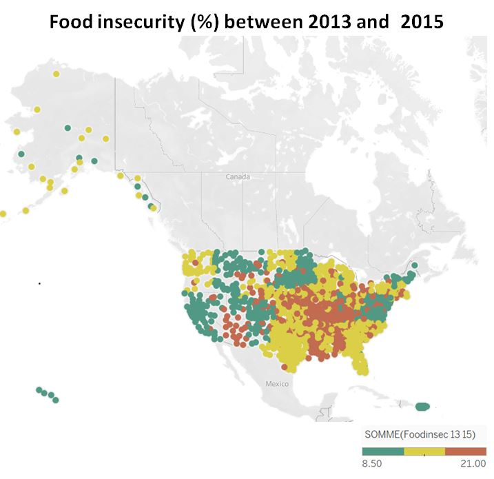

```python
Image("D:/Food_insecurity.JPG")
```

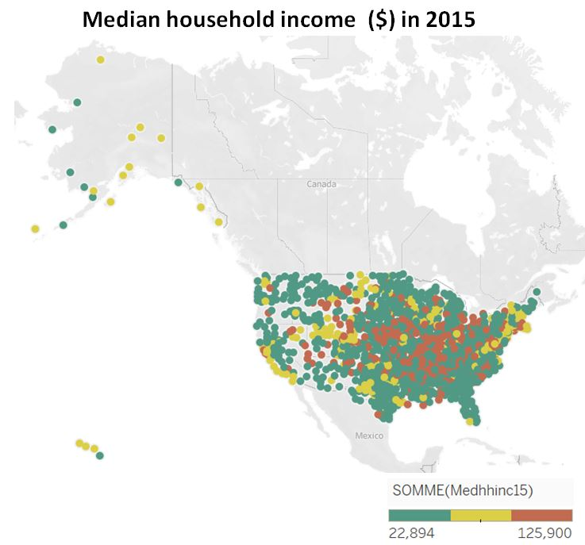

```python
Image("D:/INCOME.JPG")
```

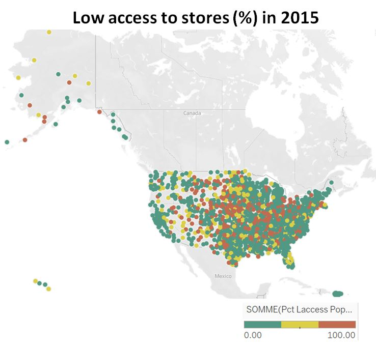

```python
Image("D:/STORE.JPG")
```

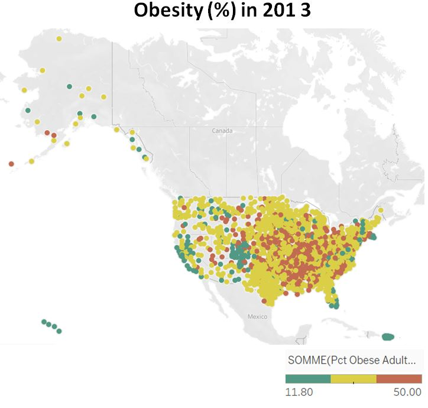

```python
Image("D:/OBESITY.JPG")
```

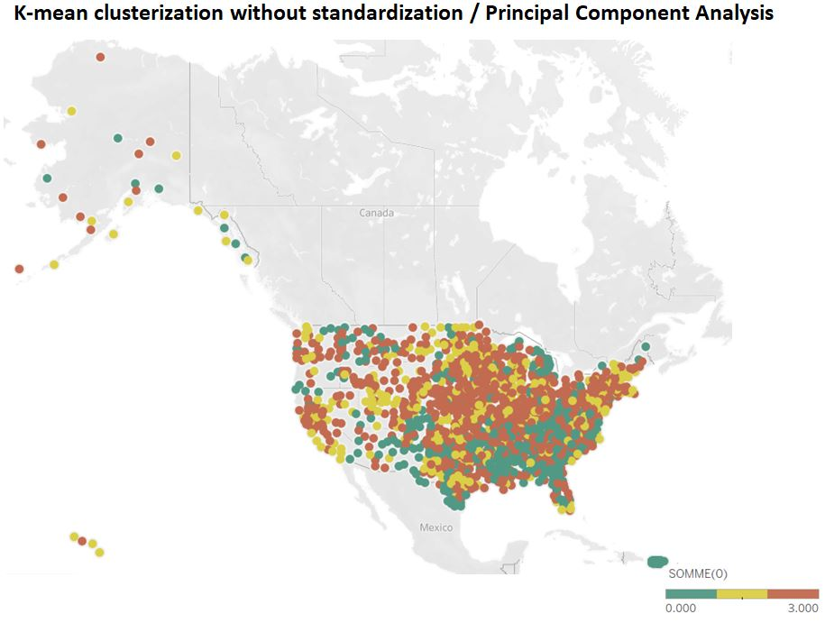

```python
Image("D:CLUSTERS.JPG")
```

With these symbol maps, we can see that (1) the counties with the highest rate of obesity seems to have the highest percentage of food insecurity, (2) the percentage of low access to stores in 2015 seems to be positively associated with the median household income in 2015.

## License

MIT License

Copyright (c) 2021 Inès François

Permission is hereby granted, free of charge, to any person obtaining a copy of this software and associated documentation files (the "Software"), to deal in the Software without restriction, including without limitation the rights to use, copy, modify, merge, publish, distribute, sublicense, and/or sell copies of the Software, and to permit persons to whom the Software is furnished to do so, subject to the following conditions:

The above copyright notice and this permission notice shall be included in all copies or substantial portions of the Software.

THE SOFTWARE IS PROVIDED "AS IS", WITHOUT WARRANTY OF ANY KIND, EXPRESS OR IMPLIED, INCLUDING BUT NOT LIMITED TO THE WARRANTIES OF MERCHANTABILITY, FITNESS FOR A PARTICULAR PURPOSE AND NONINFRINGEMENT. IN NO EVENT SHALL THE AUTHORS OR COPYRIGHT HOLDERS BE LIABLE FOR ANY CLAIM, DAMAGES OR OTHER LIABILITY, WHETHER IN AN ACTION OF CONTRACT, TORT OR OTHERWISE, ARISING FROM, OUT OF OR IN CONNECTION WITH THE SOFTWARE OR THE USE OR OTHER DEALINGS IN THE SOFTWARE.